# Homework 1

## Topic 5: Logarithmic Transforms

##### by Yige Yang, Changcheng Pu, and Karyn Ehmann

###### 02/07/2017

Log normal distributions are normally distributed after the log transform. We are starting with a dataset named “data_log” that is normally distributed with a mean of zero and a standard deviation of one. The dataset before the log distribution is then named “data” and is the exponent of “data_log”.

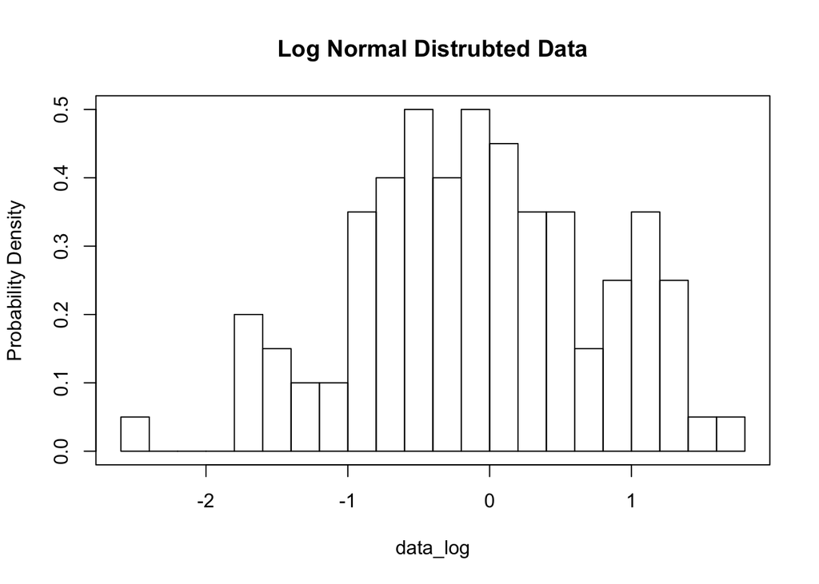

```r
data_log = rnorm(100,0,1) #the dataset after log transform
data = exp(data_log) #the dataset before log transform
hist(data_log, main = "Log Normal Distrubted Data", freq = F, ylab= 'Probability Density', breaks = 20)
box()
```

Here is an idea of how the log normal transformed dataset looks.

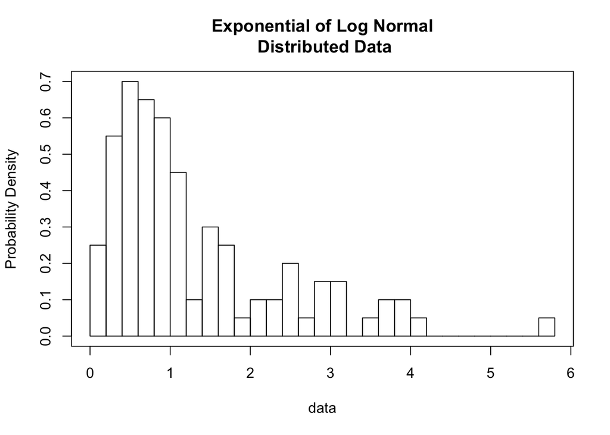

```r
hist(data, main = "Exponential of Log Normal\n Distributed Data", freq = F, ylab = 'Probability Density', breaks = 20)
box()
```

Here is an idea of how the positively skewed data prior to the log transform looks.

# Central Tendency

### Before the Log Transform

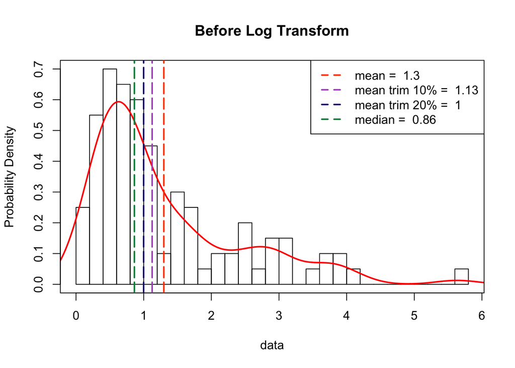

```r
#mean
mean = mean(data)

#trimmed mean
meanT10=mean(data, 0.1)
meanT20=mean(data, 0.2)

#median
median=median(data)

#hist and density & plot
d = density(data)
hist1=hist(data, freq=F, breaks=20, plot=T, ylab="Probability Density", main="Before Log Transform")
lines(d$x, d$y, col='red',lwd=2)
box()
abline(v=mean, col='orangered1', lty=5, lwd=2)
abline(v=meanT10, col='mediumorchid3', lty=5, lwd=2)
abline(v=meanT20, col='midnightblue', lty=5, lwd=2)
abline(v=median, col='springgreen4', lty=5, lwd=2)
legend('topright', legend=c(paste("mean = ", round(mean,2)), paste("mean trim 10% = ", round(meanT10,2)), paste("mean trim 20% = ", round(meanT20,2)), paste("median = ", round(median,2))), lty=rep(2,2), lwd=rep(2,2), col=c("orangered1","mediumorchid3", "midnightblue", "springgreen4"))
```

Before log transformation, mean is larger than median and is right skewed due to outliners. Trimmed means are more robust to outlines and are closer but still larger than median.

### After the Log Transform

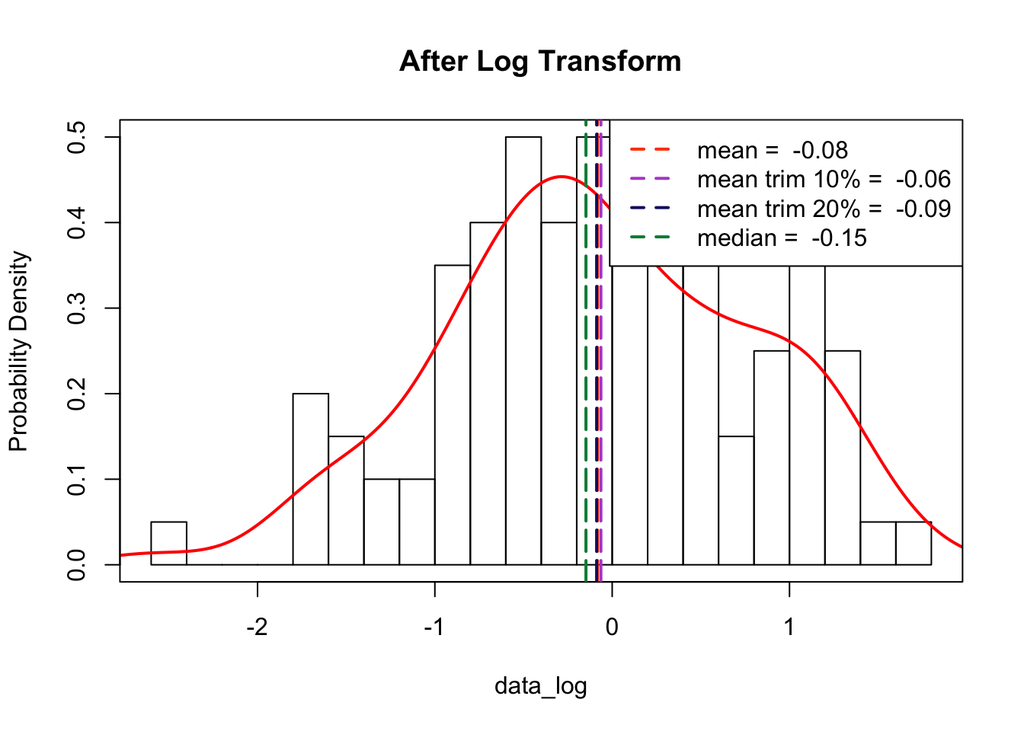

```r
#mean
mean_log = mean(data_log)

#trimmed mean
meanT10_log=mean(data_log, 0.1)
meanT20_log=mean(data_log, 0.2)

#median
median_log=median(data_log)

#hist and density & plot
d_log = density(data_log)
hist1=hist(data_log, freq=F, breaks=20, plot=T, ylab="Probability Density", main="After Log Transform")
lines(d_log$x, d_log$y, col='red',lwd=2)
box()
abline(v=mean_log, col='orangered1', lty=5, lwd=2)
abline(v=meanT10_log, col='mediumorchid3', lty=5, lwd=2)
abline(v=meanT20_log, col='midnightblue', lty=5, lwd=2)
abline(v=median_log, col='springgreen4', lty=5, lwd=2)
legend('topright', legend=c(paste("mean = ", round(mean_log,2)), paste("mean trim 10% = ", round(meanT10_log,2)), paste("mean trim 20% = ", round(meanT20_log,2)), paste("median = ", round(median_log,2))), lty=rep(2,2), lwd=rep(2,2), col=c("orangered1","mediumorchid3", "midnightblue", "springgreen4"))
```

After the log transform, the probability figure is closer to a normall distribution. peak density occurs in the middle and no tail on either side. Median and mean stay in the center of the plot, close to each other. Trimmed means are very close to mean.

# Spread

### Before the Log Transform

```r
#variance
var1 = var(data)

#standard deviation
sd1 = sd(data)

#inter-quartile range
iqr1 = IQR(data)
iqr1
```

```
## [1] 1.175103
```

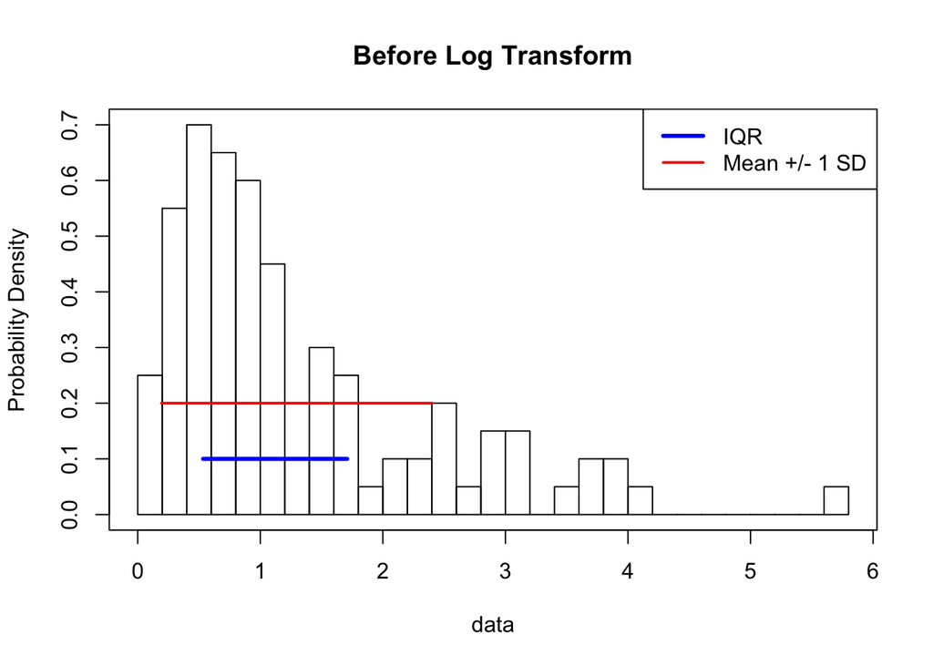

```r
#mean absolute deviation
library('lsr')
mean_ad1 = aad(data)

#median absolute deviation
median_ad1 = mad(data, constant = 1)

#spread on a histogram
hist(data, breaks = 20, main = 'Before Log Transform', ylab = "Probability Density", freq = F)
box()
lines(x = quantile(data, c(0.25,0.75)), y = c(0.1,0.1), col = 'blue', lty = 1, lwd = 3)
lines(x = c(mean+sd1, mean-sd1), y = c(0.2,0.2), col = 'red', lty = 1, lwd = 2 )
legend('topright', legend = c('IQR', 'Mean +/- 1 SD'), lwd = c(3,2),
       lty = c(1,1), col = c('blue', 'red'))
```

Before the log transform, the dataset is solely positive with a large range. The mean +/- standard deviation is larger than the interquartile range. Spread of data is not a robust statistic and is impacted by the positive skew.

### After the Log Transform

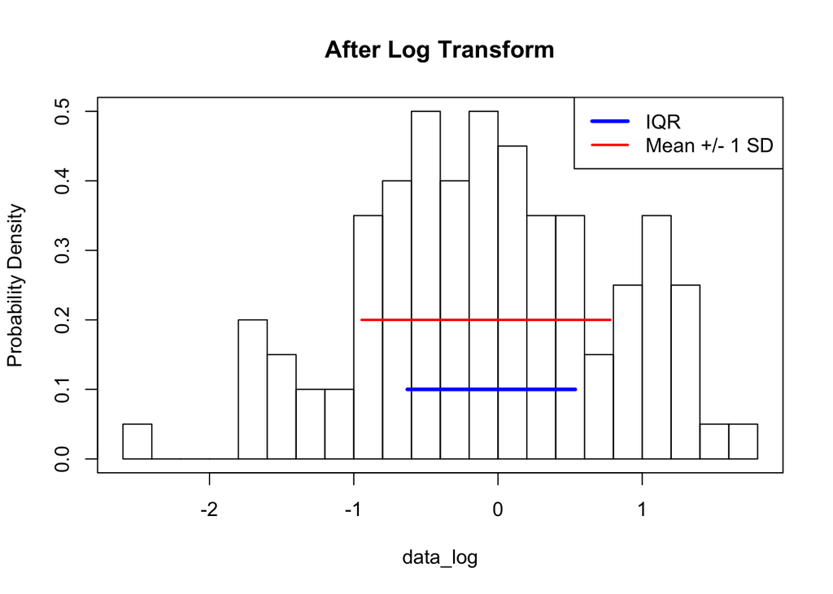

```r
#variance
var2 = var(data_log)

#standard deviation
sd2 = sd(data_log)

#inter-quartile range
iqr2 = IQR(data_log)

#mean absolute deviation
mean_ad2 = aad(data_log)

#median absolute deviation
median_ad2 = mad(data_log, constant = 1)

#spread on a histogram
hist(data_log, breaks = 20, main = 'After Log Transform', ylab = "Probability Density", freq = F)
box()
lines(x = quantile(data_log, c(0.25,0.75)), y = c(0.1,0.1), col = 'blue', lty = 1, lwd = 3)
lines(x = c(mean_log+sd2, mean_log-sd2), y = c(0.2,0.2), col = 'red', lty = 1, lwd = 2 )
legend('topright', legend = c('IQR', 'Mean +/- 1 SD'), lwd = c(3,2),
       lty = c(1,1), col = c('blue', 'red'))
```

### Before the Log Transform

```r
#skewness
library('moments')
sk0=skewness(data)
sk0
```

```
## [1] 1.443462
```

```r
np=length(data)
sk1=(1/(np-1))*sum((data-mean(data))^3)/(sd(data)^3)
sk1
```

```
## [1] 1.436226
```

```r
#Yule-Kendall index
quants=quantile(data, c(0.25, 0.5, 0.75))
skYK=((quants[3]-quants[2])-(quants[2]-quants[1]))/(quants[3]-quants[1])
skYK
```

```
##       75%
## 0.4400854
```

### After the Log Transform

```r
#skewness
sk0_log=skewness(data_log)
sk0_log
```

```
## [1] -0.1580518
```

```r
np_log=length(data_log)
sk1_log=(1/(np-1))*sum((data_log-mean(data_log))^3)/(sd(data_log)^3)
sk1_log
```

```
## [1] -0.1572596
```

```r
#Yule-Kendall index
quants_log=quantile(data_log, c(0.25, 0.5, 0.75))
skYK_log=((quants[3]-quants[2])-(quants[2]-quants[1]))/(quants[3]-quants[1])
skYK_log
```

```
##       75%
## 0.4400854
```

Overall, the log transform drastically changes the distribution of data and is useful when interpreting positively skewed datasets. The central tendency, spread, and symmetry are altered when the log transform is applied and the log normal distributed data is able to better represent the data as a whole.